# Resolución Actividad 3-Grupal Máster Bioinformática UNIR (2025)

## 2.4 Interpretación de gráficos de PCA

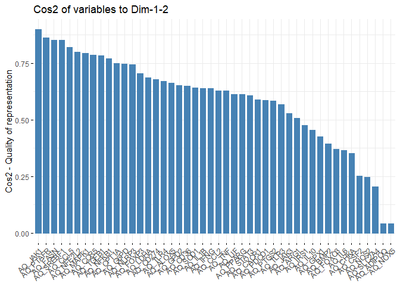

```r
#Visualizar importancia de cada variable en PC1 y PC2
fviz_cos2(pca_result, choice = "var", axes = 1:2)
```

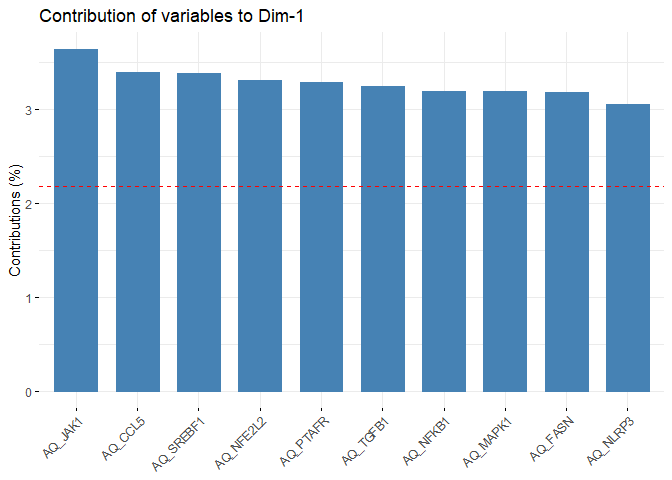

```r
#Visualizar variabls mas importantes en PC1
fviz_contrib(pca_result, choice = "var", axes = 1,top = 10 )
```

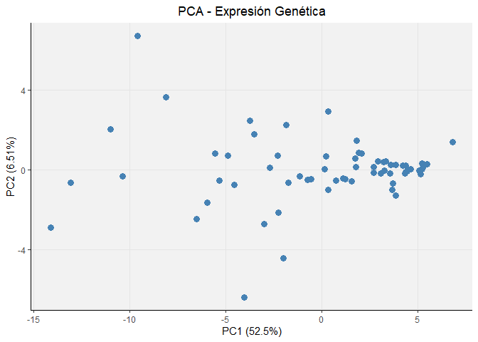

```r
#Etiquetas de los ejes para el gráfico de dispersion

x_label <- paste0("PC1 (", round(varianza_explicada[1] * 100, 2), "%)")
y_label <- paste0("PC2 (", round(varianza_explicada[2] * 100, 2), "%)")

#Generar grafico de dispersion de los dos primeros componentes

ggplot(pca_df, aes(x=PC1, y=PC2))+
  geom_point(size = 3, color = "steelblue") +
  labs(title = "PCA - Expresión Genética", x = x_label, y = y_label)+
  theme_classic() +
  theme(panel.grid.major = element_line(color = "gray90"),
        panel.background = element_rect(fill = "gray95"),
        plot.title = element_text(hjust = 0.5))
```

El gráfico “Cos2 of variables to Dim-1-2” muestra las barras más altas indican que la variable está mejor representada por esos componentes, lo que significa que su variabilidad se explica bien en el espacio bidimensional de PC1 y PC2. Este gráfico ayuda a identificar qué genes son capturados más eficazmente por los principales ejes de variación.

El gráfico “Contribution of variables to Dim-1” las barras más altas indican una mayor contribución porcentual.

El “PCA - Expresión Genética” (Gráfico de Dispersión PC1 vs. PC2. El eje X representa el Componente Principal 1 (PC1), que explica el 52.5% de la varianza total, mientras que el eje Y representa el Componente Principal 2 (PC2), que explica el 6.51% de la varianza. Cada punto en el gráfico corresponde a un individuo, y la proximidad entre los puntos sugiere similitudes en su patrón de expresión génica. La dispersión de los puntos indica la heterogeneidad de los individuos a lo largo de estas dos dimensiones principales. Un análisis de la agrupación o separación de los puntos puede revelar patrones o clústeres naturales dentro de la población estudiada basados en su perfil de expresión génica.